# Maturity estimation for aquatic species through the AquaticLifeHistory package

Jonathan Smart

2023-11-17

# Citation

Please cite this package if it is used in any publication. The citation details can be accessed in the command line:

```r
citation("AquaticLifeHistory")
```

```
#>
#>   Smart J 2023 AquaticLifeHistory: Fisheries life history analysis
#>   using contemporary methods.
#>   https://github.com/jonathansmart/AquaticLifeHistory
#>
#>   Smart, J. J., Chin, A. , Tobin, A. J. and Simpfendorfer, C. A. (2016)
#>   Multimodel approaches in shark and ray growth studies: strengths,
#>   weaknesses and the future. Fish and Fisheries, 17: 955-971.
#>   doi:10.1111/faf.12154
#>
#> To see these entries in BibTeX format, use 'print(<citation>,
#> bibtex=TRUE)', 'toBibtex(.)', or set
#> 'options(citation.bibtex.max=999)'.
```

# Introduction

Maturity estimation is performed by fitting a maturity ogive to binary maturity statuses for either length or age data. Maturity ogives are fitted using a glm with a logit link function and usually with a binomial error structure (but we’ll touch on this soon). A glm of this sort is fitted in R using:

```r
glm(formula = Maturity~Age,data = my.data, family = "binomial")
```

The default link function for a binomial error structure is the logit link function. Therefore this does not need to be specified.

All maturity analyses using a logistic ogive are fitted in this manner and this is the basic operation occurring in all the maturity functions in the `AquaticLifeHistory` package. However, getting all of the information needed to produce analyses for publication can involve several steps with a few different decisions needed. Therefore the `Estimate_Age_Maturity` and `Estimate_Len_Maturity` functions handle much of these additional steps. However, it is important for the user to understand that these are basically wrapper functions around a glm call. As such the analyses inside these functions are simple to implement outside of this package.

The `Estimate_Age_Maturity` and `Estimate_Len_Maturity` functions perform the following:

- Estimate the length or age at 50% ($L_{50}$ or $A_{50}$ ) and 95% ($L_{95}$ or $A_{95}$) maturity with standard errors. Standard errors are important outputs and should always be reported for parameters.
- Bootstrap the data with a specified number of iterations to produce 95% confidence intervals about the curve
- Produce a plot of either:
  - A standard logistic ogive with a binomial error structure. This is fit to binary data.
  - A binned logistic ogive with a quasi binomial error structure. This is fit to proportion mature data for specified length or age bins. These bins are created inside the function using a specified bin width.
- Return the parameter estimates, plots of the maturity ogive or the predicted ogive fits with bootstrapped estimates for the user to produce their own plots (recommended if the outputs are meant for publication).

# Input data

The input data for both `Estimate_Age_Maturity` and `Estimate_Len_Maturity` functions require an age or length variable as well as a binary maturity variable. These functions accept various column headings for flexibility. For example `Estimate_Len_Maturity` will accept a column named “Length”, “Len”, “STL”, “TL”, “LT” or “size” (plus others) as the input column for the length variable. However, the maturity and age columns must have names that begin with “mat” and “age”, respectively. The variable names needed by the functions are **not** case sensitive.

A data set for female silky sharks (*Carcharhinus falciformis*) from Papua New Guinea is included as example data. This shows the typical format accepted by both functions.

```r
library(AquaticLifeHistory)
data("maturity_data")
head(maturity_data)
```

```
#>     Tag Age Length Maturity
#> 1 10001  12    178        0
#> 2 10004  10    165        0
#> 3 10011   9    140        0
#> 4 10013   8    144        0
#> 5 10016   0     91        0
#> 6 10019  10    158        0
```

```r
# Maturity variable is binary (immature = 0, mature = 1)
range(maturity_data$Maturity)
```

```
#> [1] 0 1
```

# Using `Estimate_Age_Maturity`

Both maturity functions produce very similar outputs based on either age or length data. They are built to handle the same data set so there is no need to subset your data for just length or age. Each function will identify the variables it needs and will ignore the others.

The `Estimate_Age_Maturity` function unsurprisingly estimates age-at-maturity. In doing so it gives you a choice of model:

- Binomial model fitted to binary data
- Quasi binomial model fitted to binned proportion mature data

The input data is the same for both as the age bins are handled automatically.

## Binomial model

The default call to `Estimate_Age_Maturity` will return your parameters with their standard errors (which you should **ALWAYS** report). The SE’s are the asymptotic errors from the logistic ogive

```r
Estimate_Age_Maturity(maturity_data)
```

[output not shown]

However, if you would like to get a little more out of this function, you can have it return a plot with bootstrapped confidence intervals around the curve

```
#> Bootstrapping logistic model with a binomial error structure
```

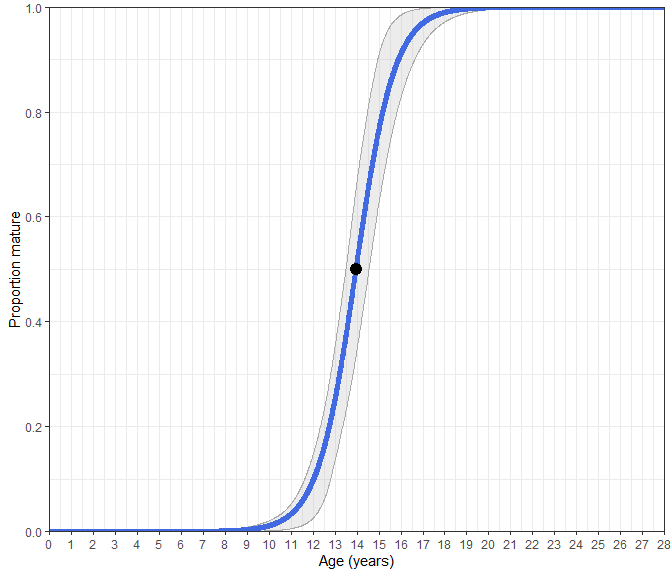

```r
# selecting return = "plot" returns a ggplot object rather than the parameters.
Estimate_Age_Maturity(maturity_data, return = "plot", n.bootstraps = 1000)
```

Additionally, you can display the binary data by setting `display.points = TRUE`

```
#> Bootstrapping logistic model with a binomial error structure
```

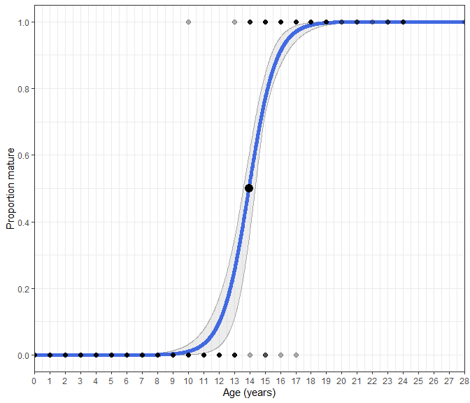

```r
# selecting return = "plot" returns a ggplot object rather than the parameters.
Estimate_Age_Maturity(maturity_data, return = "plot", n.bootstraps = 1000, display.points = TRUE)
```

## Quasibinomial (binned) model

An alternative approach is to bin the data by age class and determine the proportion mature in each age class. This is performed by selecting `error.structure = "quasibinomial"`. Within the function, the binary data is binned by age and the model is fitted with the quasi binomial structure with each age bin weighted by its sample size. Doing so often returns similar parameter estimates:

```r
Estimate_Age_Maturity(maturity_data)

Estimate_Age_Maturity(maturity_data, error.structure = "quasibinomial")
```

[output not shown]

However, a different plot is returned with stacked bars showing the proportion mature. The sample size of each bin is displayed above it.

```
#> Bootstrapping logistic model with a quasibinomial error structure
```

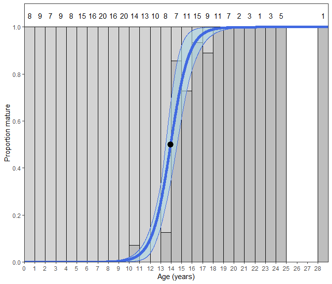

```r
# selecting return = "plot" returns a ggplot object rather than the parameters.
Estimate_Age_Maturity(maturity_data, return = "plot", n.bootstraps = 1000, error.structure = "quasibinomial")
```

With regards to age - both logistic model options return almost identical ogives. Therefore, the decision of which to use is up to the user.

# Using `Estimate_Len_Maturity`

Estimating length-at-maturity is handled the same as age was previously but with its own function. All of the arguments are the same with one exception (which we’ll get to shortly).

You can get the parameters:

```r
Estimate_Len_Maturity(maturity_data)
```

[output not shown]

A plot of the binomial model with the the option of displaying the points

```
#> Bootstrapping logistic model with a binomial error structure
```

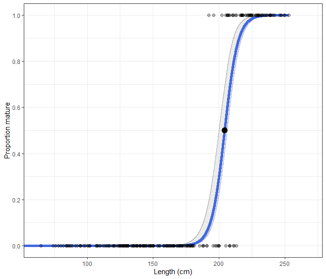

```r
# selecting return = "plot" returns a ggplot object rather than the parameters.
Estimate_Len_Maturity(maturity_data, return = "plot", n.bootstraps = 1000, display.points = TRUE)
```

As the length unit can differ between data sets, the function determines whether cm or mm are being used and will adjust the axis as needed.

```
#> Bootstrapping logistic model with a binomial error structure
```

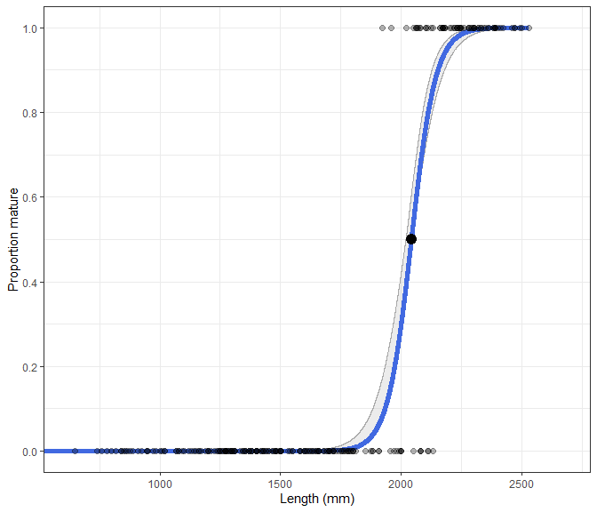

```r
new_data <- maturity_data
new_data$Length <- new_data$Length*10

Estimate_Len_Maturity(new_data, return = "plot", n.bootstraps = 1000, display.points = TRUE)
```

## Quasibinomial (binned) model

An additional argument is needed to use a quasi binomial model. Previously, we binned age by year class as there is no other sensible way to go about this. However, for length the bin width needs to be specified and this is very important. This is done using the `bin.width` argument.

```
#> Bootstrapping logistic model with a quasibinomial error structure
```

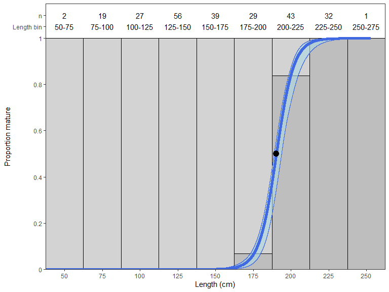

```r
# selecting return = "plot" returns a ggplot object rather than the parameters.
Estimate_Len_Maturity(maturity_data,
                      return = "plot",
                      n.bootstraps = 1000,
                      error.structure = "quasibinomial",
                      bin.width = 25)
```

Note that because now we have to chose the bin width, this can influence results:

```r
# Binomial model
Estimate_Len_Maturity(maturity_data)

# Length in 10 cm bins
Estimate_Len_Maturity(maturity_data,
                      error.structure = "quasibinomial",
                      bin.width = 10)

# Length in 25 cm bins
Estimate_Len_Maturity(maturity_data,
                      error.structure = "quasibinomial",
                      bin.width = 25)

# Length in 30 cm bins
Estimate_Len_Maturity(maturity_data,
                      error.structure = "quasibinomial",
                      bin.width = 30)
```

[output not shown]

In each instance the $L_{50}$ changed which means that judicious choice of length bin is needed. Therefore, I usually advocate that for length-at-maturity you should used a binomial model with binary data as this avoids introducing potential bias. It should be noted that this is only an issue for length as binning data for age does not require decisions on bin width and therefore avoids biasing the results.

Therefore, if you plan on binning length data make sure you think things through carefully.

# Retrieving logistic model estimates

```r
# selecting return = "plot" returns a ggplot object rather than the parameters.
Mat_at_age_estimates <- Estimate_Age_Maturity(maturity_data,
                                              return = "estimates",
                                              n.bootstraps = 1000,
                                              error.structure = "quasibinomial")


Mat_at_len_estimates <- Estimate_Len_Maturity(maturity_data,
                                              return = "estimates",
                                              n.bootstraps = 1000,
                                              error.structure = "binomial")

head(Mat_at_age_estimates)

head(Mat_at_len_estimates)
```

```
#> Bootstrapping logistic model with a quasibinomial error structure
#> Bootstrapping logistic model with a binomial error structure
#>    Age     Estimate         high          low
#> 1 0.00 1.240623e-07 6.382676e-08 7.774546e-06
#> 2 0.01 1.254845e-07 6.456597e-08 7.840418e-06
#> 3 0.02 1.269231e-07 6.531378e-08 7.906848e-06
#> 4 0.03 1.283781e-07 6.607027e-08 7.973841e-06
#> 5 0.04 1.298498e-07 6.683556e-08 8.041402e-06
#> 6 0.05 1.313384e-07 6.760975e-08 8.109536e-06
#>   Length     Estimate         high          low
#> 1   0.00 2.220446e-16 2.220446e-16 2.220446e-16
#> 2   0.01 2.220446e-16 2.220446e-16 2.220446e-16
#> 3   0.02 2.220446e-16 2.220446e-16 2.220446e-16
#> 4   0.03 2.220446e-16 2.220446e-16 2.220446e-16
#> 5   0.04 2.220446e-16 2.220446e-16 2.220446e-16
#> 6   0.05 2.220446e-16 2.220446e-16 2.220446e-16
```